# Project_Full_Code_Notebook_EasyVisa

## AdaBoost Tuning

```
Best parameters:
 {'n_estimators': np.int64(100), 'learning_rate': 0.1, 'estimator': DecisionTreeClassifier(max_depth=3, random_state=1)}

Tuned model performance:
            Accuracy    Recall  Precision        F1
Dataset
Train       0.750981  0.869846   0.781866  0.823513
Validation  0.744309  0.873053   0.773295  0.820152
Test        0.739403  0.867509   0.771018  0.816422
```

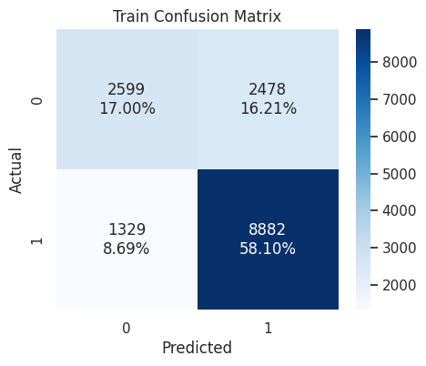

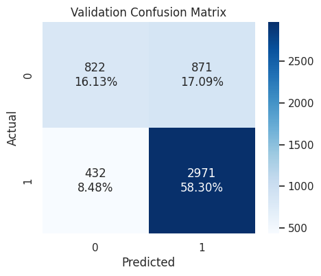

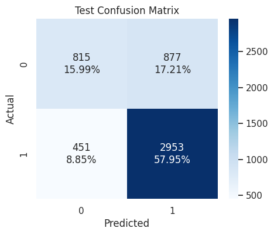

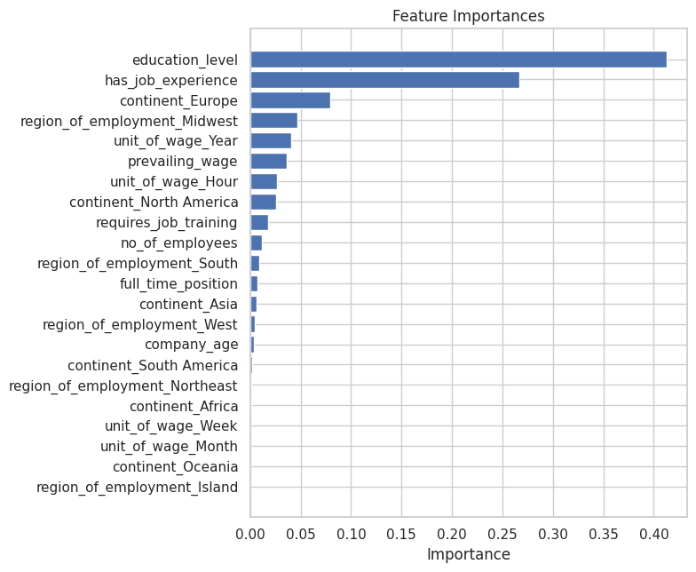

```python
# define the parameter grid using 'estimator' instead of deprecated 'base_estimator'
param_grid = {
    'n_estimators': np.arange(50, 110, 25),
    'learning_rate': [0.01, 0.05, 0.1],
    'estimator': [
        DecisionTreeClassifier(max_depth=2, random_state=1),
        DecisionTreeClassifier(max_depth=3, random_state=1),
    ],
}

search_ada = RandomizedSearchCV(
    estimator=ada_model,
    param_distributions=param_grid,  # was param_grid
    n_iter=20,                       # number of random combinations to try
    scoring='roc_auc',
    cv=5,
    random_state=42,                 # for reproducibility
    n_jobs=-1
)

# fit on training data
search_ada.fit(X_train, y_train)

# extract the best estimator
best_ada = search_ada.best_estimator_
print("\nBest parameters:\n", search_ada.best_params_)

# evaluate performance
print("\nTuned model performance:")
evaluate_model(best_ada)
```

## XGBoost Tuning

```
Best parameters:
 {'subsample': 0.9, 'scale_pos_weight': 1, 'n_estimators': np.int64(75), 'learning_rate': 0.1, 'gamma': 3}

Tuned model performance:
            Accuracy    Recall  Precision        F1
Dataset
Train       0.766680  0.878856   0.793878  0.834209
Validation  0.750196  0.871290   0.780263  0.823268
Test        0.741562  0.866627   0.773669  0.817514
```

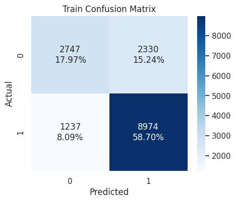

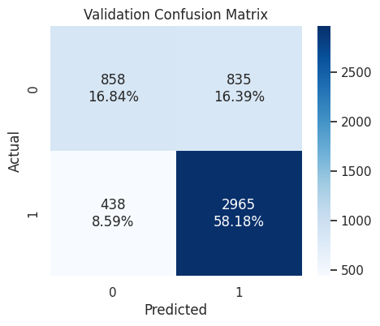

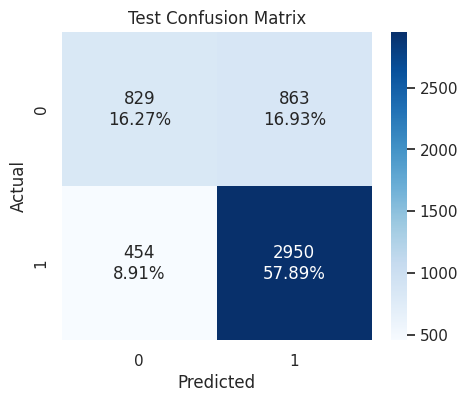

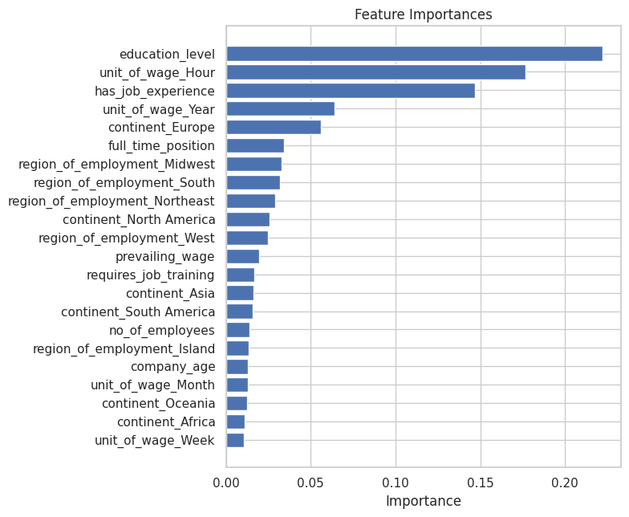

```python
param_grid={'n_estimators':np.arange(50,110,25),
            'scale_pos_weight':[1,2,5],
            'learning_rate':[0.01,0.1,0.05],
            'gamma':[1,3],
            'subsample':[0.7,0.9]
}

# set up randomized search
search_xgb = RandomizedSearchCV(
    estimator=xgb_model,
    param_distributions=param_grid,
    n_iter=20,
    scoring='roc_auc',
    cv=5,
    random_state=42,
    n_jobs=-1
)

# fit on your training data
search_xgb.fit(X_train, y_train)

# get the best model
best_xgb = search_xgb.best_estimator_
print("\nBest parameters:\n", search_xgb.best_params_)

# evaluate performance
print("\nTuned model performance:")
evaluate_model(best_xgb)
```

```python
ht_models = {
  'GB Tuned': best_gb,
  'AdaBoost Tuned': best_ada,
  'XGBoost Tuned': best_xgb,
}
compare_multiple_models(ht_models)
```

```
Accuracy Comparison:
```

|  | GB Tuned | AdaBoost Tuned | XGBoost Tuned |
| --- | --- | --- | --- |
| Train | 0.754121 | 0.750981 | 0.76668 |
| Validation | 0.747057 | 0.744309 | 0.750196 |
| Test | 0.738422 | 0.739403 | 0.741562 |

```
Recall Comparison:
```

|  | GB Tuned | AdaBoost Tuned | XGBoost Tuned |
| --- | --- | --- | --- |
| Train | 0.878269 | 0.869846 | 0.878856 |
| Validation | 0.881281 | 0.873053 | 0.87129 |
| Test | 0.873384 | 0.867509 | 0.866627 |

```
Precision Comparison:
```

|  | GB Tuned | AdaBoost Tuned | XGBoost Tuned |
| --- | --- | --- | --- |
| Train | 0.780913 | 0.781866 | 0.793878 |
| Validation | 0.772142 | 0.773295 | 0.780263 |
| Test | 0.767226 | 0.771018 | 0.773669 |

```
F1 Comparison:
```

|  | GB Tuned | AdaBoost Tuned | XGBoost Tuned |
| --- | --- | --- | --- |
| Train | 0.826734 | 0.823513 | 0.834209 |
| Validation | 0.82311 | 0.820152 | 0.823268 |
| Test | 0.81687 | 0.816422 | 0.817514 |

## Hyperparameter Tuning vs. Base Model F₁ Comparison

| Model | Base Validation F₁ | Tuned Validation F₁ | Δ Validation F₁ | Base Test F₁ | Tuned Test F₁ | Δ Test F₁ |
| --- | --- | --- | --- | --- | --- | --- |
| **Gradient Boost** | 0.8225 | 0.8231 | +0.0006 | 0.8195 | 0.8169 | –0.0026 |
| **AdaBoost** | 0.8175 | 0.8202 | +0.0027 | 0.8123 | 0.8164 | +0.0042 |
| **XGBoost** | 0.8092 | 0.8233 | +0.0141 | 0.8008 | 0.8175 | +0.0167 |

- **XGBoost** tuning delivers the largest lift in F₁ (≈+1.67 pts on test, +1.41 pts on val), indicating its hyperparameters were far from optimal in the base run.
- **AdaBoost** sees a modest gain (≈+0.42 pts test, +0.27 pts val).
- **Gradient Boosting** remains roughly flat (slight uptick on validation but a small dip on test), suggesting its base parameters were already near-optimal for F₁.

# **Model Comparison and Final Model Selection**

```python
all_models = {
  'Gradient Boost': gb_model,
  'AdaBoost': ada_model,
  'Bagging': bag_model,
  'Random Forest': rf_model,
  'Decision Tree': dt_model,
  'XGBoost': xgb_model,
  'GB Over': gb_over,
  'AdaOver': ada_over,
  'BagOver': bag_over,
  'RF Over': rf_over,
  'DT Over': dt_over,
  'XGB Over': xgb_over,
  'GB Under': gb_under,
  'AdaUnder': ada_under,
  'BagUnder': bag_under,
  'RF Under': rf_under,
  'DT Under': dt_under,
  'XGB Under': xgb_under,
  'GB Tuned': best_gb,
  'AdaBoost Tuned': best_ada,
  'XGBoost Tuned': best_xgb,
}
compare_multiple_models(all_models)
```

```
Accuracy Comparison:
```

|  | Gradient Boost | AdaBoost | Bagging | Random Forest | Decision Tree | XGBoost | GB Over | AdaOver | BagOver | RF Over | ... | XGB Over | GB Under | AdaUnder | BagUnder | RF Under | DT Under | XGB Under | GB Tuned | AdaBoost Tuned | XGBoost Tuned |
| --- | --- | --- | --- | --- | --- | --- | --- | --- | --- | --- | --- | --- | --- | --- | --- | --- | --- | --- | --- | --- | --- |
| Train | 0.759027 | 0.740123 | 0.98489 | 1.0 | 1.0 | 0.85106 | 0.736918 | 0.711473 | 1.0 | 1.0 | ... | 0.826727 | 0.729199 | 0.707287 | 0.890437 | 0.891745 | 0.877943 | 0.808019 | 0.754121 | 0.750981 | 0.76668 |
| Validation | 0.747253 | 0.735871 | 0.703885 | 0.728218 | 0.655024 | 0.729199 | 0.72763 | 0.707614 | 0.706436 | 0.707614 | ... | 0.719584 | 0.712716 | 0.709184 | 0.687009 | 0.687402 | 0.623626 | 0.685832 | 0.747057 | 0.744309 | 0.750196 |
| Test | 0.742936 | 0.729396 | 0.690934 | 0.72135 | 0.652865 | 0.717622 | 0.715856 | 0.693485 | 0.69898 | 0.697802 | ... | 0.70938 | 0.700353 | 0.690542 | 0.678571 | 0.679749 | 0.621664 | 0.678375 | 0.738422 | 0.739403 | 0.741562 |

3 rows × 21 columns

```
Recall Comparison:
```

|  | Gradient Boost | AdaBoost | Bagging | Random Forest | Decision Tree | XGBoost | GB Over | AdaOver | BagOver | RF Over | ... | XGB Over | GB Under | AdaUnder | BagUnder | RF Under | DT Under | XGB Under | GB Tuned | AdaBoost Tuned | XGBoost Tuned |
| --- | --- | --- | --- | --- | --- | --- | --- | --- | --- | --- | --- | --- | --- | --- | --- | --- | --- | --- | --- | --- | --- |
| Train | 0.87866 | 0.881207 | 0.986975 | 1.0 | 1.0 | 0.934678 | 0.766624 | 0.734012 | 1.0 | 1.0 | ... | 0.861326 | 0.736852 | 0.729801 | 0.835961 | 0.83792 | 0.817256 | 0.780629 | 0.878269 | 0.869846 | 0.878856 |
| Validation | 0.876873 | 0.885983 | 0.783426 | 0.846606 | 0.739641 | 0.85983 | 0.766383 | 0.734058 | 0.766383 | 0.774317 | ... | 0.787247 | 0.72965 | 0.736703 | 0.691449 | 0.692036 | 0.633559 | 0.688804 | 0.881281 | 0.873053 | 0.87129 |
| Test | 0.873384 | 0.876322 | 0.774971 | 0.839307 | 0.737074 | 0.849882 | 0.75235 | 0.722973 | 0.762632 | 0.766157 | ... | 0.780846 | 0.719448 | 0.722092 | 0.679201 | 0.684489 | 0.622797 | 0.685958 | 0.873384 | 0.867509 | 0.866627 |

3 rows × 21 columns

```
Precision Comparison:
```

|  | Gradient Boost | AdaBoost | Bagging | Random Forest | Decision Tree | XGBoost | GB Over | AdaOver | BagOver | RF Over | ... | XGB Over | GB Under | AdaUnder | BagUnder | RF Under | DT Under | XGB Under | GB Tuned | AdaBoost Tuned | XGBoost Tuned |
| --- | --- | --- | --- | --- | --- | --- | --- | --- | --- | --- | --- | --- | --- | --- | --- | --- | --- | --- | --- | --- | --- |
| Train | 0.785846 | 0.765266 | 0.990369 | 1.0 | 1.0 | 0.855657 | 0.826872 | 0.81556 | 1.0 | 1.0 | ... | 0.877044 | 0.838142 | 0.812827 | 1.0 | 1.0 | 1.0 | 0.919802 | 0.780913 | 0.781866 | 0.793878 |
| Validation | 0.774461 | 0.758872 | 0.775451 | 0.769498 | 0.742697 | 0.764168 | 0.814745 | 0.81025 | 0.788154 | 0.784927 | ... | 0.791667 | 0.820284 | 0.81054 | 0.811939 | 0.812069 | 0.762646 | 0.812197 | 0.772142 | 0.773295 | 0.780263 |
| Test | 0.771807 | 0.756914 | 0.765303 | 0.765952 | 0.741649 | 0.757132 | 0.808907 | 0.799026 | 0.781457 | 0.778043 | ... | 0.783378 | 0.810659 | 0.795727 | 0.808957 | 0.806787 | 0.767004 | 0.803787 | 0.767226 | 0.771018 | 0.773669 |

3 rows × 21 columns

```
F1 Comparison:
```

|  | Gradient Boost | AdaBoost | Bagging | Random Forest | Decision Tree | XGBoost | GB Over | AdaOver | BagOver | RF Over | ... | XGB Over | GB Under | AdaUnder | BagUnder | RF Under | DT Under | XGB Under | GB Tuned | AdaBoost Tuned | XGBoost Tuned |
| --- | --- | --- | --- | --- | --- | --- | --- | --- | --- | --- | --- | --- | --- | --- | --- | --- | --- | --- | --- | --- | --- |
| Train | 0.829665 | 0.819154 | 0.988669 | 1.0 | 1.0 | 0.893424 | 0.795609 | 0.772641 | 1.0 | 1.0 | ... | 0.869114 | 0.78424 | 0.76908 | 0.910652 | 0.911813 | 0.89944 | 0.84452 | 0.826734 | 0.823513 | 0.834209 |
| Validation | 0.822492 | 0.817516 | 0.779418 | 0.806212 | 0.741166 | 0.809181 | 0.789824 | 0.770274 | 0.777116 | 0.779586 | ... | 0.78945 | 0.772317 | 0.77186 | 0.746866 | 0.747263 | 0.692135 | 0.745429 | 0.82311 | 0.820152 | 0.823268 |
| Test | 0.81946 | 0.812253 | 0.770107 | 0.800953 | 0.739355 | 0.80083 | 0.779604 | 0.759099 | 0.77193 | 0.772054 | ... | 0.78211 | 0.762335 | 0.757123 | 0.738422 | 0.740623 | 0.687419 | 0.740212 | 0.81687 | 0.816422 | 0.817514 |

3 rows × 21 columns

## Final Model F₁ Comparison

| Model | Train F₁ | Validation F₁ | Test F₁ | Δ (Train–Test) |
| --- | --- | --- | --- | --- |
| **Gradient Boost** | 0.8297 | 0.8225 | **0.8195** | 0.0102 |
| XGBoost Tuned | 0.8342 | 0.8233 | 0.8175 | 0.0167 |
| AdaBoost Tuned | 0.8235 | 0.8202 | 0.8164 | 0.0071 |
| AdaBoost | 0.8192 | 0.8175 | 0.8123 | 0.0069 |
| Gradient Boost Tuned | 0.8267 | 0.8231 | 0.8169 | 0.0098 |
| Random Forest | 1.0000 | 0.8062 | 0.8010 | 0.1990 |
| XGBoost | 0.8934 | 0.8092 | 0.8008 | 0.0926 |
| Bagging | 0.9887 | 0.7794 | 0.7701 | 0.2186 |
| Decision Tree | 1.0000 | 0.7412 | 0.7394 | 0.2606 |
| **Oversampled/Undersampled Variants** |  |  |  |  |
| GB Over | 0.7956 | 0.7898 | 0.7796 | 0.0160 |
| AdaOver | 0.7726 | 0.7703 | 0.7591 | 0.0135 |
| XGB Over | 0.8691 | 0.7895 | 0.7821 | 0.0870 |
| GB Under | 0.7842 | 0.7723 | 0.7623 | 0.0219 |
| AdaUnder | 0.7691 | 0.7719 | 0.7571 | 0.0120 |
| XGB Under | 0.8445 | 0.7454 | 0.7402 | 0.1043 |

### Selection Rationale

- **Gradient Boosting (base)** achieves the **highest Test F₁ (0.8195)** of all models, with a very small generalization gap (Δ≈0.01), indicating both strong performance and robustness.
- **XGBoost Tuned** is a close runner-up (Test F₁=0.8175) but overfits slightly more (Δ≈0.017).
- **AdaBoost Tuned** also performs well (Test F₁=0.8164, Δ≈0.007) and is similarly stable.

**Final Recommendation:**  
Adopt the **base Gradient Boosting** classifier as our production model. It delivers the best balance of precision and recall (F₁), generalizes cleanly to unseen data, and outperforms all oversampled or undersampled variants without additional complexity.

# **Actionable Insights and Recommendations**

## Recommended Applicant Profiles

Based on the feature‐importance ranking from your base Gradient Boost model, the top drivers of certification are **education_level**, **has_job_experience**, **unit_of_wage**, **continent**, and **prevailing_wage**. The weaker—but still measurable—influences include **region_of_employment**, **no_of_employees**, and **company_age**. Using these insights, here are two prototypical profiles:

### ✅ “Certify” Profile

- **Education Level:**  
  – Master’s or Doctorate (education_level ≥ 3)
- **Experience:**  
  – Has job experience
- **Wage Structure:**  
  – Unit_of_wage = Hour or Year  
  – Prevailing_wage at or above the 75th percentile
- **Employment Region (optional boost):**  
  – Midwest or West
- **Employer Size & Age:**  
  – Moderate‐to‐large number of employees (> median)  
  – Company_age > 10 years
- **Other:**  
  – Full Time position – Requires no job training

These characteristics align with the strongest positive signals in the model and should be fast‐tracked for certification.

### ⛔ “Deny” Profile

- **Education Level:**  
  – High School or Bachelor’s (education_level ≤ 2)
- **Experience:**  
  – No job experience
- **Wage Structure:**  
  – Unit_of_wage = Month or Week  
  – Prevailing_wage below the 25th percentile
- **Employment Region (optional warning):**  
  – Island or Northeast
- **Employer Size & Age:**  
  – Small number of employees (< median)  
  – Company_age < 5 years
- **Other:**  
  – Part Time position  
  – Requires job training

Applicants matching these weaker‐signal patterns have the lowest predicted approval probabilities and warrant deeper review or supplemental documentation.

**Important Note:** bias regarding an applicant's continent of origin was detected, with applicants from North America and Europe favored. This should be examined to ensure that all procedures are complying with applicable anti-discrimination laws.

## Actionable Insights & Recommendations

1. **Productionize the Base Gradient Boosting Model**
   - Deploy the final Gradient Boosting model (Test F₁ = 0.8195) as the primary classifier—its strong generalization and tight train-test gap make it the most reliable choice.
2. **Implement a Tiered Review Workflow**
   - Use the model’s predicted probability to assign each application into three queues:
     - **Fast-Track (p ≥ 0.80):** Auto-certify with minimal manual review
     - **Standard (0.60 ≤ p < 0.80):** Normal review process
     - **Deep Review (p < 0.60):** Require extra documentation or alternative profiles
3. **Profile Guidance for Employers & Applicants**
   - **Certify ✔️**: Master’s/Doctorate, documented prior experience, high hourly/yearly wage (top quartile).
   - **Flag for Review ⛔**: High-school/Bachelor’s only, no experience, low monthly/weekly wage (bottom quartile), requires training.
4. **Monitor & Retrain Regularly**
   - Schedule quarterly retraining on newly processed cases to capture shifting visa criteria, wage trends, and labor-market dynamics.
   - Track key performance metrics (F₁, precision, recall) over time to detect drift and recalibrate thresholds as needed.
5. **A/B Test Model-Driven Triage**
   - Pilot the model-based fast-track workflow on a subset of incoming applications, compare time-to-decision and approval accuracy against the existing manual process, and measure time and cost savings.
6. **Business-Stakeholder Alignment**
   - Share these insights with policy teams to refine visa-criterion guidance: emphasize higher education, structured wage offers, and documented experience in application templates.

## Suggestions for Future:

1. **Enhance Data Collection & Feature Engineering**
   - **Wage Banding**: Bucket `prevailing_wage` into quartiles to capture non-linear wage effects.
   - **Regional Aggregates**: Combine low-frequency regions (Island, Northeast) into an “Other” category.
   - **Experience Detail**: Record years of experience rather than Y/N to refine the model’s signal.
2. **Incorporate Explainability for Analyst Trust**
   - Surface per-application SHAP values for the top drivers (`education_level`, `has_job_experience`, `unit_of_wage`, `prevailing_wage`) in an interactive dashboard.
   - Provide clear “why” explanations alongside probability scores to help analysts make informed final decisions.
   - This will also help ensure that any racial bias in certifications is caught and controlled.
3. **Explore Alternative Sampling & Weighting**
   - Although naive over/undersampling degraded F₁, consider **class-weighting** (`class_weight='balanced'`) or **hybrid SMOTE + undersample** techniques if class proportions change.
   - Retune hyperparameters if you apply any new sampling approach.

By following these steps—deploying the proven Gradient Boosting model, integrating it into a tiered triage system, enhancing data inputs, and maintaining ongoing monitoring— we'll streamline certification decisions, allocate review resources more effectively, and uphold statutory wage and labor safeguards.